# Michael Jenks

## Nascar Stage Racing Data

Nascar Races are broken up into 3 stages. At the end of the first 2 stages, points are awarded to the top 10 finishers in that stage. The 3rd stage has no points given out because when the 3rd stage ends the race is over. Points are given out from 10 to 1 in order of finishing So, 1st place receives 10 points, 2nd receives 9, and so on all the way to 10th, who receives 1 point. The driver who wins the stage is awarded one "playoff point". Playoff points are a part of a in depth playoff system. Basically, when the regular season ends, each driver's points is reset back to a specific value plus the amount of playoff points they gathered. A race win awards a driver 5 playoff points. Drivers can then start earning points in that round through stage points. Nascar playoffs follow a round by round format. Each round is 3 races and at the end of the three races 4 drivers are eliminated based on points. 16 drivers make the playoffs. The final round is 1 race with the highest finishing driver remaining in the playoffs becoming the champion. At the start of each round, the drivers playoff points are awarded to them. For example, if Driver A wins 4 races and 6 stages, they enter the playoffs with 26 playoff points. Compared Driver B with 0 playoff points, Driver A will enter the playoffs with a 26 point advantage. Stage Results from the full 2023 Nascar season for the 3 different series are recorded below. The "Class A" series, known as the Cup Series, starts at race_id 5268 and ends at 5310. The "Class B" series, known as Xfinity series, begins at race_ID 5310 and ends at 5343. The "Class C" series, known as the Crafstman Truck Series, begins at 5343 and goes on until the end of the dataset. Data recorded includes stage number, driver name, driver_ID, race_ID, car number, finishing position for that stage, and points awarded. The dataset is comprised of 1850 rows.

```python
import pandas as pd
import requests
import io
```

```python
import matplotlib.pyplot as plt
plt.close("all")
```

```python
import numpy as np
```

```python
nascar = pd.read_csv("2023_race_stage_results.csv")
print(nascar)
```

```
      race_id  stage_number   driver_fullname  driver_id  car_number  \
0        5268             1   Brad Keselowski       1816           6
1        5268             1       Ryan Preece       4070          41
2        5268             1    Chris Buescher       3989          17
3        5268             1     Kevin Harvick       1416           4
4        5268             1  Michael McDowell       3832          34
...       ...           ...               ...        ...         ...
1845     5373             2        Ben Rhodes       4107          99
1846     5373             2       Chase Purdy       4295           4
1847     5373             2    Grant Enfinger       3978          23
1848     5373             2       Jake Garcia       4423          35
1849     5373             2    Carson Hocevar       4326          42

      finishing_position  stage_points
0                      1            10
1                      2             9
2                      3             8
3                      4             7
4                      5             6
...                  ...           ...
1845                   6             0
1846                   7             4
1847                   8             0
1848                   9             2
1849                  10             0

[1850 rows x 7 columns]
```

Reading the csv file into the codespace and naming the pandas dataframe

Here are some potential questions we can use to aid our analysis that some people observing the dataset might ask:

1. Which driver scored the most stage points across all 3 series?
2. Which driver scored the most stage points in each series?
3. Did any driver(s) score max stage points (20) in any races this season?
4. What car number across all 3 series scored the most stage points?
5. What driver scored stage points in the most stages?
6. In what race did the most drivers score stage points in?
7. Who scored the most playoff points through stage wins?
8. Repeat each of the following questions but group results based on the series.
9. What is one informational plot we can construct to show the data?

First, lets start by cleaning the data and the data frame. Setp 1 will be to rename the columns to something more fluent

```python
nascar = nascar.rename(columns={"stage_number": "StageNumber", "driver_fullname": "DriverName", "car_number": "CarNumber", "finishing_position": "StageResult", "race_id":"raceID", "driver_id": "DriverID", "stage_points":"StagePoints"})
print(nascar)
```

```
      raceID  StageNumber        DriverName  DriverID  CarNumber  StageResult  \
0       5268            1   Brad Keselowski      1816          6            1
1       5268            1       Ryan Preece      4070         41            2
2       5268            1    Chris Buescher      3989         17            3
3       5268            1     Kevin Harvick      1416          4            4
4       5268            1  Michael McDowell      3832         34            5
...      ...          ...               ...       ...        ...          ...
1845    5373            2        Ben Rhodes      4107         99            6
1846    5373            2       Chase Purdy      4295          4            7
1847    5373            2    Grant Enfinger      3978         23            8
1848    5373            2       Jake Garcia      4423         35            9
1849    5373            2    Carson Hocevar      4326         42           10

      StagePoints
0              10
1               9
2               8
3               7
4               6
...           ...
1845            0
1846            4
1847            0
1848            2
1849            0

[1850 rows x 7 columns]
```

Now, lets try to clean up the race ID to list races starting with 1

```python
nascar['raceID'] = nascar['raceID'] - 5267
print(nascar)
```

```
      raceID  StageNumber        DriverName  DriverID  CarNumber  StageResult  \
0          1            1   Brad Keselowski      1816          6            1
1          1            1       Ryan Preece      4070         41            2
2          1            1    Chris Buescher      3989         17            3
3          1            1     Kevin Harvick      1416          4            4
4          1            1  Michael McDowell      3832         34            5
...      ...          ...               ...       ...        ...          ...
1845     106            2        Ben Rhodes      4107         99            6
1846     106            2       Chase Purdy      4295          4            7
1847     106            2    Grant Enfinger      3978         23            8
1848     106            2       Jake Garcia      4423         35            9
1849     106            2    Carson Hocevar      4326         42           10

      StagePoints
0              10
1               9
2               8
3               7
4               6
...           ...
1845            0
1846            4
1847            0
1848            2
1849            0

[1850 rows x 7 columns]
```

Now, we have raceID starting with 1 to indicate the first race, and 106 to indiciate the last.

Another peice of data cleaning we can do is splitting the data based on the series. This will be useful when we conduct analysis on each series We will also adjust the raceId accordinly in each series.

The Cup Series goes from rows 0 through 730:

```python
CupSeries = nascar.iloc[0:730, 0:7]
```

```python
print(CupSeries)
```

```
     raceID  StageNumber        DriverName  DriverID  CarNumber  StageResult  \
0         1            1   Brad Keselowski      1816          6            1
1         1            1       Ryan Preece      4070         41            2
2         1            1    Chris Buescher      3989         17            3
3         1            1     Kevin Harvick      1416          4            4
4         1            1  Michael McDowell      3832         34            5
..      ...          ...               ...       ...        ...          ...
725      42            2       Ryan Blaney      4023         12            6
726      42            2       Kyle Larson      4030          5            7
727      42            2     Bubba Wallace      4025         23            8
728      42            2   Brad Keselowski      1816          6            9
729      42            2        Erik Jones      4059         43           10

     StagePoints
0             10
1              9
2              8
3              7
4              6
..           ...
725            0
726            0
727            3
728            2
729            1

[730 rows x 7 columns]
```

The Xfinity Series goes from rows 731 to 1390

```python
XfinSeries = nascar.iloc[730:1390, 0:7]
```

```python
print(XfinSeries)
```

```
      raceID  StageNumber       DriverName  DriverID  CarNumber  StageResult  \
730       43            1      Austin Hill      4133         21            1
731       43            1   Chandler Smith      4312         16            2
732       43            1  Justin Allgaier        34          7            3
733       43            1     Justin Haley      4172         10            4
734       43            1       Jeb Burton      4018         27            5
...      ...          ...              ...       ...        ...          ...
1385      75            2    Brandon Jones      4085          9            6
1386      75            2       Josh Berry      4123          8            7
1387      75            2    Sheldon Creed      4204          2            8
1388      75            2  Justin Allgaier        34          7            9
1389      75            2     Riley Herbst      4269         98           10

      StagePoints
730            10
731             9
732             8
733             0
734             6
...           ...
1385            5
1386            4
1387            3
1388            0
1389            1

[660 rows x 7 columns]
```

```python
XfinSeries['raceID'] = XfinSeries['raceID'] - 42
print(XfinSeries)
```

```
      raceID  StageNumber       DriverName  DriverID  CarNumber  StageResult  \
730        1            1      Austin Hill      4133         21            1
731        1            1   Chandler Smith      4312         16            2
732        1            1  Justin Allgaier        34          7            3
733        1            1     Justin Haley      4172         10            4
734        1            1       Jeb Burton      4018         27            5
...      ...          ...              ...       ...        ...          ...
1385      33            2    Brandon Jones      4085          9            6
1386      33            2       Josh Berry      4123          8            7
1387      33            2    Sheldon Creed      4204          2            8
1388      33            2  Justin Allgaier        34          7            9
1389      33            2     Riley Herbst      4269         98           10

      StagePoints
730            10
731             9
732             8
733             0
734             6
...           ...
1385            5
1386            4
1387            3
1388            0
1389            1

[660 rows x 7 columns]
```

The Truck series goes from rows 1390 to the last row, 1850.

```python
TruckSeries = nascar.iloc[1390:1850, 0:7]
```

```python
print(TruckSeries)
```

```
      raceID  StageNumber        DriverName  DriverID  CarNumber  StageResult  \
1390      76            1   Christian Eckes      4268         19            1
1391      76            1      Matt Crafton       694         88            2
1392      76            1  Matt DiBenedetto      3916         25            3
1393      76            1     Hailie Deegan      4366         13            4
1394      76            1  Nicholas Sanchez      4416          2            5
...      ...          ...               ...       ...        ...          ...
1845     106            2        Ben Rhodes      4107         99            6
1846     106            2       Chase Purdy      4295          4            7
1847     106            2    Grant Enfinger      3978         23            8
1848     106            2       Jake Garcia      4423         35            9
1849     106            2    Carson Hocevar      4326         42           10

      StagePoints
1390           10
1391            9
1392            8
1393            7
1394            6
...           ...
1845            0
1846            4
1847            0
1848            2
1849            0

[460 rows x 7 columns]
```

```python
TruckSeries['raceID'] = TruckSeries['raceID'] - 75
print(TruckSeries)
```

```
      raceID  StageNumber        DriverName  DriverID  CarNumber  StageResult  \
1390       1            1   Christian Eckes      4268         19            1
1391       1            1      Matt Crafton       694         88            2
1392       1            1  Matt DiBenedetto      3916         25            3
1393       1            1     Hailie Deegan      4366         13            4
1394       1            1  Nicholas Sanchez      4416          2            5
...      ...          ...               ...       ...        ...          ...
1845      31            2        Ben Rhodes      4107         99            6
1846      31            2       Chase Purdy      4295          4            7
1847      31            2    Grant Enfinger      3978         23            8
1848      31            2       Jake Garcia      4423         35            9
1849      31            2    Carson Hocevar      4326         42           10

      StagePoints
1390           10
1391            9
1392            8
1393            7
1394            6
...           ...
1845            0
1846            4
1847            0
1848            2
1849            0

[460 rows x 7 columns]
```

The data is now cleaned and split in a way we can use effectively and efficiently.

**Question 1 and 2: Who had the most stage points across Nascar's 3 series?**

For investigating which driver had the most stage points across all series, we'll use our original dataset. Lets group the data by either driver name or dirver id and sum up stage points.

```python
MostPoints = nascar.groupby('DriverName')['StagePoints'].sum()
print(MostPoints)
```

```
DriverName
AJ Allmendinger      61
Alex Bowman         105
Alex Labbe            6
Anthony Alfredo      23
Aric Almirola        37
                   ...
Tyler Reddick       259
Will Rodgers          5
William Byron       294
William Sawalich     16
Zane Smith          214
Name: StagePoints, Length: 107, dtype: int64
```

Now, lets sort the values in descending order to see who the best drivers in terms of stage points were. We'll display the 10 best for simplicity

```python
MostPoints.sort_values(ascending = False).head(10)
```

```
DriverName
Justin Allgaier     364
John H. Nemechek    343
Cole Custer         314
Denny Hamlin        310
Austin Hill         302
William Byron       294
Kyle Larson         277
Tyler Reddick       259
Martin Truex Jr     250
Christopher Bell    240
Name: StagePoints, dtype: int64
```

**Lets answer the same question conditioning on the 3 series**

We'll use the individual dataset for each series to accomplish this task and repeat the process we used for all of Nascar

Starting with the Cup Series:

```python
CupPoints = CupSeries.groupby('DriverName')['StagePoints'].sum()
print(CupPoints)
```

```
DriverName
AJ Allmendinger         61
Alex Bowman            105
Aric Almirola           37
Austin Cindric          63
Austin Dillon           55
Brad Keselowski        214
Bubba Wallace          134
Carson Hocevar           0
Chase Briscoe           54
Chase Elliott          116
Chris Buescher         110
Christopher Bell       240
Corey LaJoie            11
Corey Lajoie             2
Daniel Suárez          108
Denny Hamlin           310
Erik Jones              40
Harrison Burton          6
Jenson Button            1
Jimmie Johnson           4
Joey Logano            146
Jordan Taylor            3
Justin Haley            15
Kevin Harvick          157
Kyle Busch             135
Kyle Larson            277
Martin Truex Jr        250
Michael McDowell        98
Noah Gragson            14
Ricky Stenhouse Jr      38
Ross Chastain          204
Ryan Blaney            219
Ryan Preece             54
Shane Van Gisbergen     15
Todd Gilliland           8
Ty Dillon               14
Ty Gibbs               101
Tyler Reddick          259
William Byron          294
Name: StagePoints, dtype: int64
```

Sorting in descedning order and displaying best 10:

```python
CupPoints.sort_values(ascending=False).head(10)
```

```
DriverName
Denny Hamlin        310
William Byron       294
Kyle Larson         277
Tyler Reddick       259
Martin Truex Jr     250
Christopher Bell    240
Ryan Blaney         219
Brad Keselowski     214
Ross Chastain       204
Kevin Harvick       157
Name: StagePoints, dtype: int64
```

Now we'll advance to the Xfinity Series and once again repeat the process

```python
XfinPoints = XfinSeries.groupby('DriverName')['StagePoints'].sum()
print(XfinPoints)
```

```
DriverName
AJ Allmendinger        0
Alex Bowman            0
Alex Labbe             6
Anthony Alfredo       23
Aric Almirola          0
Austin Dillon          0
Austin Hill          302
Brandon Jones        135
Brett Moffitt         47
Carson Hocevar         0
Chandler Smith       210
Cole Custer          314
Connor Mosack          8
Dale Earnhardt Jr      9
Daniel Hemric        160
Denny Hamlin           0
Derek Kraus           19
Jeb Burton            28
Jeffrey Earnhardt      1
Jeremy Clements        9
Joe Graf Jr            6
John H. Nemechek     343
Jordan Taylor          0
Josh Berry           181
Josh Bilicki           5
Josh Williams          6
Justin Allgaier      364
Justin Haley           0
Kaz Grala             25
Kyle Busch             0
Kyle Larson            0
Kyle Sieg              4
Myatt Snider          17
Parker Kligerman     116
Parker Retzlaff       28
Riley Herbst         169
Ryan Sieg             34
Ryan Truex            41
Sage Karam            14
Sam Mayer            167
Sammy Smith          168
Sheldon Creed        221
Stefan Parsons         1
Trevor Bayne          30
Ty Gibbs               0
William Byron          0
Zane Smith             0
Name: StagePoints, dtype: int64
```

Sroting by Stage Points in desceding order and displaying best 10:

```python
XfinPoints.sort_values(ascending=False).head(10)
```

```
DriverName
Justin Allgaier     364
John H. Nemechek    343
Cole Custer         314
Austin Hill         302
Sheldon Creed       221
Chandler Smith      210
Josh Berry          181
Riley Herbst        169
Sammy Smith         168
Sam Mayer           167
Name: StagePoints, dtype: int64
```

Repating the process one final time for the truck series:

```python
TruckPoints = TruckSeries.groupby('DriverName')['StagePoints'].sum()
print(TruckPoints)
```

```
DriverName
Austin Hill            0
Austin Wayne Self      3
Bayley Currey         21
Ben Rhodes           136
Bret Holmes           10
Bubba Wallace          0
Carson Hocevar       165
Carson Kvapil          0
Chase Briscoe          0
Chase Purdy           73
Christian Eckes      190
Christopher Bell       0
Colby Howard          15
Corey Heim           231
Daniel Dye             2
David Gilliland        7
Dean Thompson         32
Derek Kraus            0
Grant Enfinger       142
Hailie Deegan         18
Jack Wood              4
Jake Drew              6
Jake Garcia           19
Joey Logano            0
John H. Nemechek       0
Kaden Honeycutt       10
Kaz Grala              0
Kyle Busch             0
Kyle Larson            0
Lawless Alan           9
Layne Riggs            9
Matt Crafton          72
Matt DiBenedetto      90
Matt Mills             0
Nicholas Sanchez     160
Parker Kligerman       6
Rajah Caruth          49
Ross Chastain          0
Stewart Friesen       90
Tanner Gray           65
Taylor Gray           41
Timmy Hill             2
Ty Majeski           209
Tyler Ankrum          47
Will Rodgers           5
William Byron          0
William Sawalich      16
Zane Smith           214
Name: StagePoints, dtype: int64
```

```python
TruckPoints.sort_values(ascending=False).head(10)
```

```
DriverName
Corey Heim          231
Zane Smith          214
Ty Majeski          209
Christian Eckes     190
Carson Hocevar      165
Nicholas Sanchez    160
Grant Enfinger      142
Ben Rhodes          136
Stewart Friesen      90
Matt DiBenedetto     90
Name: StagePoints, dtype: int64
```

From the results generated, we see 3 Xfinity Series drivers were the best at getting stage points across all of Nascar in 2023. Justin Allgaier, John Hunter Nemechek, and Cole Custer paced the field. Behind them, followed one Cup driver, Denny Hamlin and Xfinity driver Austin Hill. The remaining top 10 were Cup Series drivers. One important note to follow throughout this analysis how the champions in each series performed. The champion of the Cup Series was Ryan Blaney who came 13th overall and 7th in his series. In the Xfinity Series, Cole Custer was the champion. He finished 3rd in overall stage points and 3rd in his series. The Truck Series Champion was Ben Rhoades who was 8th in terms of stage points in the truck series.

**Question 3: Did any driver(s) score max stage points (20) in any races this season? If so how many times?**

To answer this question, we'll have to utlize many different goruping and aggregate functions.

Lets start by manipulating the data set to only include drivers who earned 20 points in a race.

To do this, we will group by race ID and driver name and sum up stage points

```python
Points = nascar.groupby(['DriverName', 'raceID'])['StagePoints'].sum().reset_index()
print(Points)
```

```
           DriverName  raceID  StagePoints
0     AJ Allmendinger       1            3
1     AJ Allmendinger       6            8
2     AJ Allmendinger      17            6
3     AJ Allmendinger      22            7
4     AJ Allmendinger      23            4
...               ...     ...          ...
1240       Zane Smith      99           20
1241       Zane Smith     100            5
1242       Zane Smith     102           12
1243       Zane Smith     103           15
1244       Zane Smith     106           17

[1245 rows x 3 columns]
```

Now, we only want to include drivers who scored 20 points in a single race

```python
MaxPointsTemp = Points[Points['StagePoints'] == 20]
print(MaxPointsTemp)
```

```
            DriverName  raceID  StagePoints
318    Christian Eckes     103           20
334   Christopher Bell      24           20
342   Christopher Bell      35           20
355        Cole Custer      44           20
378        Cole Custer      70           20
387         Corey Heim      80           20
402         Corey Heim     105           20
475       Denny Hamlin      33           20
506     Grant Enfinger      91           20
570   John H. Nemechek      50           20
584   John H. Nemechek      66           20
585   John H. Nemechek      67           20
612         Josh Berry      61           20
628    Justin Allgaier      46           20
638    Justin Allgaier      58           20
648    Justin Allgaier      69           20
744        Kyle Larson      39           20
771    Martin Truex Jr      26           20
774    Martin Truex Jr      29           20
829   Nicholas Sanchez      88           20
924      Ross Chastain       2           20
986         Ryan Truex      52           20
1144        Ty Majeski     100           20
1191     William Byron       3           20
1201     William Byron      20           20
1240        Zane Smith      99           20
```

Finally, let's use the count function to see how many times each driver accomplished this feet.

```python
MaxTimesTemp = MaxPointsTemp.groupby('DriverName').count()
```

```python
print(MaxTimesTemp)
```

```
                  raceID  StagePoints
DriverName
Christian Eckes        1            1
Christopher Bell       2            2
Cole Custer            2            2
Corey Heim             2            2
Denny Hamlin           1            1
Grant Enfinger         1            1
John H. Nemechek       3            3
Josh Berry             1            1
Justin Allgaier        3            3
Kyle Larson            1            1
Martin Truex Jr        2            2
Nicholas Sanchez       1            1
Ross Chastain          1            1
Ryan Truex             1            1
Ty Majeski             1            1
William Byron          2            2
Zane Smith             1            1
```

The above table does give us how many times driver's won both stages, (20 points means driver gets 10 points in each stage, therefore they win both stages), but the column names are unclear. We'll rename one of these columns and delete the other. Let's rename one column to count.

```python
MaxTimes = MaxTimesTemp.rename(columns={'raceID': 'count'}).drop('StagePoints', axis = 1)
```

```python
print(MaxTimes)
```

```
                  count
DriverName
Christian Eckes       1
Christopher Bell      2
Cole Custer           2
Corey Heim            2
Denny Hamlin          1
Grant Enfinger        1
John H. Nemechek      3
Josh Berry            1
Justin Allgaier       3
Kyle Larson           1
Martin Truex Jr       2
Nicholas Sanchez      1
Ross Chastain         1
Ryan Truex            1
Ty Majeski            1
William Byron         2
Zane Smith            1
```

Now, we have a comprehensive table of how many times each driver won both stages in a Nascar race. With over 100 races in the dataset, winning both stages seems like a rare occurence! 6 Cup drivers, 5 Xfinity drivers, and 6 Truck drivers make up this list. John Hunter Nemechek and Justin Allgaier accomplished this task the most times, 3 each. Let's once again remember the champions of each series. Interestingly enough, Cole Custer, the Xfinity Series Champion, was the only one to win both stages in a race out of the champions of each series.

Let's move on to Question 4

**Question 4: What car number scored the most points across all of Nascar?**

This task should be relatively simple and very similar to question 1. We will use the same process: grouping, sorting, and summing.

We'll start with the nascar dataset and repeat over every series

```python
CarStagePoints = nascar.groupby('CarNumber')['StagePoints'].sum()
print(CarStagePoints)
```

```
CarNumber
0     314
1     394
2     449
3      55
4     240
5     309
6     214
7     389
8     317
9     269
10     79
11    678
12    219
13     18
```

[output cut: 43 more lines]

```python
CarStagePoints = CarStagePoints.sort_values(ascending = False)
print(CarStagePoints)
```

```
CarNumber
11    678
20    583
19    540
2     449
1     394
7     389
98    378
24    357
16    318
8     317
0     314
5     309
21    308
23    276
```

[output cut: 43 more lines]

From the result, across all 3 series the number 11 gathered the most stage points over the 2023 season.

Now let's quickly repeat for each series.

```python
CupNumberPts = CupSeries.groupby('CarNumber')['StagePoints'].sum()
print(CupNumberPts)
```

```
CarNumber
1     204
2      63
3      55
4     157
5     277
6     214
7      13
8     135
9     119
10     37
11    310
12    219
14     54
15      1
```

[output cut: 23 more lines]

```python
CupNumberPts = CupNumberPts.sort_values(ascending=False)
print(CupNumberPts)
```

```
CarNumber
11    310
24    294
5     277
45    259
19    250
20    240
12    219
6     214
1     204
4     157
22    146
8     135
23    134
9     119
```

[output cut: 23 more lines]

```python
XfinNumberPts = XfinSeries.groupby('CarNumber')['StagePoints'].sum()
print(XfinNumberPts)
```

```
CarNumber
0     314
1     167
2     221
7     367
8     182
9     135
10     42
11    137
16    210
17      0
18    168
19    100
20    343
21    302
```

[output cut: 18 more lines]

```python
XfinNumberPts = XfinNumberPts.sort_values(ascending = False)
print(XfinNumberPts)
```

```
CarNumber
7     367
20    343
0     314
21    302
2     221
16    210
8     182
98    169
18    168
1     167
11    137
9     135
48    116
19    100
```

[output cut: 18 more lines]

```python
TruckNumberPts = TruckSeries.groupby('CarNumber')['StagePoints'].sum()
print(TruckNumberPts)
```

```
CarNumber
1      23
2     165
4      83
5      32
7       9
9      15
11    231
13     18
15     65
16     47
17     41
19    190
22      3
23    142
```

[output cut: 19 more lines]

```python
TruckNumberPts = TruckNumberPts.sort_values(ascending = False)
print(TruckNumberPts)
```

```
CarNumber
11    231
38    214
98    209
19    190
2     165
42    165
23    142
99    136
52     90
25     90
4      83
88     72
15     65
24     49
```

[output cut: 19 more lines]

One important note from this analysis is that the driver list of stage points from above should match the car number list. We can quickly confirm this intuition:

```python
Check = nascar.groupby(['DriverName', 'CarNumber'])['StagePoints'].sum()
print(Check)
```

```
DriverName        CarNumber
AJ Allmendinger   10             0
                  16            61
Alex Bowman       17             0
                  48           105
Alex Labbe        91             6
                              ...
William Byron     24           294
                  51             0
William Sawalich  1             16
Zane Smith        28             0
                  38           214
Name: StagePoints, Length: 140, dtype: int64
```

```python
Check = Check.sort_values(ascending = False).head(10)
print(Check)
```

```
DriverName        CarNumber
Justin Allgaier   7            364
John H. Nemechek  20           343
Cole Custer       0            314
Denny Hamlin      11           310
Austin Hill       21           302
William Byron     24           294
Kyle Larson       5            277
Tyler Reddick     45           259
Martin Truex Jr   19           250
Christopher Bell  20           240
Name: StagePoints, dtype: int64
```

Sure enough, the lists match. One note about these lists is that drivers may appear more than once due to competiting in different series. Points are only awarded to drivers who are fulltime in the series.

**Question 5: What driver scored stage points in the most stages?**

To think about this question, we will be grouping by driver name and raceID. we will also utilizing the count function again. When the new table is subset, we will simply count how many times a driver's name appears. Since every driver that appears in the dataset scored stage points in a race at some point this season, we can add up the number of times a driver appears to find the number of stages they scored in. Then we will sort the table in descending order.

```python
nascar_sub = nascar[['DriverName', 'raceID', 'StagePoints']]
print(nascar_sub)
```

```
            DriverName  raceID  StagePoints
0      Brad Keselowski       1           10
1          Ryan Preece       1            9
2       Chris Buescher       1            8
3        Kevin Harvick       1            7
4     Michael McDowell       1            6
...                ...     ...          ...
1845        Ben Rhodes     106            0
1846       Chase Purdy     106            4
1847    Grant Enfinger     106            0
1848       Jake Garcia     106            2
1849    Carson Hocevar     106            0

[1850 rows x 3 columns]
```

```python
timesScored = nascar_sub.groupby(['DriverName', 'raceID']).count()
timesScored = timesScored.rename(columns = {'StagePoints': 'TimesScored'})
print(timesScored)
```

```
                        TimesScored
DriverName      raceID
AJ Allmendinger 1                 1
                6                 1
                17                1
                22                1
                23                2
...                             ...
Zane Smith      99                2
                100               2
                102               2
                103               2
                106               2

[1245 rows x 1 columns]
```

```python
timesScored = timesScored.groupby('DriverName')['TimesScored'].sum()
print(timesScored)
```

```
DriverName
AJ Allmendinger     23
Alex Bowman         21
Alex Labbe           1
Anthony Alfredo      5
Aric Almirola       12
                    ..
Tyler Reddick       42
Will Rodgers         1
William Byron       52
William Sawalich     6
Zane Smith          34
Name: TimesScored, Length: 107, dtype: int64
```

```python
timesScored = timesScored.sort_values(ascending=False)
print(timesScored)
```

```
DriverName
Kyle Larson          53
William Byron        52
John H. Nemechek     51
Justin Allgaier      51
Cole Custer          50
                     ..
Josh Williams         1
Carson Kvapil         1
Stefan Parsons        1
Austin Wayne Self     1
Kyle Sieg             1
Name: TimesScored, Length: 107, dtype: int64
```

From the results across all of nascar, we see that 2 cup drivers led Kyle Larson and William Byron scored points in the most stages. Let's look at each series individually and repeat the process.

```python
Cup_sub = CupSeries[['DriverName', 'raceID', 'StagePoints']]
print(Cup_sub)
```

```
           DriverName  raceID  StagePoints
0     Brad Keselowski       1           10
1         Ryan Preece       1            9
2      Chris Buescher       1            8
3       Kevin Harvick       1            7
4    Michael McDowell       1            6
..                ...     ...          ...
725       Ryan Blaney      42            0
726       Kyle Larson      42            0
727     Bubba Wallace      42            3
728   Brad Keselowski      42            2
729        Erik Jones      42            1

[730 rows x 3 columns]
```

```python
CuptimesScored = Cup_sub.groupby(['DriverName', 'raceID']).count()
CuptimesScored = CuptimesScored.rename(columns = {'StagePoints': 'TimesScored'})
print(CuptimesScored)
```

```
                        TimesScored
DriverName      raceID
AJ Allmendinger 1                 1
                6                 1
                17                1
                22                1
                23                2
...                             ...
William Byron   36                1
                37                2
                39                2
                40                2
                42                2

[504 rows x 1 columns]
```

```python
CuptimesScored = CuptimesScored.groupby('DriverName')['TimesScored'].sum()
print(CuptimesScored)
```

```
DriverName
AJ Allmendinger        14
Alex Bowman            20
Aric Almirola           9
Austin Cindric         11
Austin Dillon          11
Brad Keselowski        38
Bubba Wallace          27
Carson Hocevar          1
Chase Briscoe          14
Chase Elliott          22
Chris Buescher         21
Christopher Bell       46
Corey LaJoie            3
Corey Lajoie            2
Daniel Suárez          22
Denny Hamlin           47
Erik Jones             10
Harrison Burton         1
Jenson Button           1
Jimmie Johnson          1
Joey Logano            26
Jordan Taylor           1
Justin Haley            5
Kevin Harvick          32
Kyle Busch             26
Kyle Larson            45
Martin Truex Jr        43
Michael McDowell       17
Noah Gragson            4
Ricky Stenhouse Jr     12
Ross Chastain          32
Ryan Blaney            35
Ryan Preece            13
Shane Van Gisbergen     3
Todd Gilliland          3
Ty Dillon               3
Ty Gibbs               23
Tyler Reddick          42
William Byron          44
Name: TimesScored, dtype: int64
```

```python
CuptimesScored = CuptimesScored.sort_values(ascending=False)
print(CuptimesScored)
```

```
DriverName
Denny Hamlin           47
Christopher Bell       46
Kyle Larson            45
William Byron          44
Martin Truex Jr        43
Tyler Reddick          42
Brad Keselowski        38
Ryan Blaney            35
Kevin Harvick          32
Ross Chastain          32
Bubba Wallace          27
Kyle Busch             26
Joey Logano            26
Ty Gibbs               23
Daniel Suárez          22
Chase Elliott          22
Chris Buescher         21
Alex Bowman            20
Michael McDowell       17
AJ Allmendinger        14
Chase Briscoe          14
Ryan Preece            13
Ricky Stenhouse Jr     12
Austin Cindric         11
Austin Dillon          11
Erik Jones             10
Aric Almirola           9
Justin Haley            5
Noah Gragson            4
Todd Gilliland          3
Corey LaJoie            3
Ty Dillon               3
Shane Van Gisbergen     3
Corey Lajoie            2
Jenson Button           1
Carson Hocevar          1
Jordan Taylor           1
Harrison Burton         1
Jimmie Johnson          1
Name: TimesScored, dtype: int64
```

In this analysis, Denny Hamlin scored points in the most stages in the cup series. However, we just observed Kyle Larson had scored in the most stages. How can this be? Observing the data, we see Kyle Larson has competed in both the truck series and xfinity series this year. Because he scored stage points in those races, the nascar dataset takes that into account while the Cup series data set only included cup races where he scored stage points in Cup Series races. There is a similar case for William Byron. Also let's note Ryan Blaney, the Cup Champion, who scored points in the 8th most stages.

```python
Xfin_sub = XfinSeries[['DriverName', 'raceID', 'StagePoints']]
print(Xfin_sub)
```

```
           DriverName  raceID  StagePoints
730       Austin Hill       1           10
731    Chandler Smith       1            9
732   Justin Allgaier       1            8
733      Justin Haley       1            0
734        Jeb Burton       1            6
...               ...     ...          ...
1385    Brandon Jones      33            5
1386       Josh Berry      33            4
1387    Sheldon Creed      33            3
1388  Justin Allgaier      33            0
1389     Riley Herbst      33            1

[660 rows x 3 columns]
```

```python
XfintimesScored = Xfin_sub.groupby(['DriverName', 'raceID']).count()
XfintimesScored = XfintimesScored.rename(columns = {'StagePoints': 'TimesScored'})
print(XfintimesScored)
```

```
                        TimesScored
DriverName      raceID
AJ Allmendinger 6                 2
                12                2
                15                1
                16                2
                20                2
...                             ...
Ty Gibbs        20                2
                21                1
                22                2
William Byron   6                 2
Zane Smith      15                1

[438 rows x 1 columns]
```

```python
XfintimesScored = XfintimesScored.groupby('DriverName')['TimesScored'].sum()
print(XfintimesScored)
```

```
DriverName
AJ Allmendinger       9
Alex Bowman           1
Alex Labbe            1
Anthony Alfredo       5
Aric Almirola         3
Austin Dillon         4
Austin Hill          47
Brandon Jones        28
Brett Moffitt        13
Carson Hocevar        2
Chandler Smith       45
Cole Custer          50
Connor Mosack         2
Dale Earnhardt Jr     2
Daniel Hemric        33
Denny Hamlin          2
Derek Kraus           5
Jeb Burton            7
Jeffrey Earnhardt     1
Jeremy Clements       4
Joe Graf Jr           2
John H. Nemechek     50
Jordan Taylor         2
Josh Berry           33
Josh Bilicki          4
Josh Williams         1
Justin Allgaier      51
Justin Haley          3
Kaz Grala             7
Kyle Busch            5
Kyle Larson           6
Kyle Sieg             1
Myatt Snider          5
Parker Kligerman     30
Parker Retzlaff       8
Riley Herbst         39
Ryan Sieg             7
Ryan Truex            6
Sage Karam            2
Sam Mayer            38
Sammy Smith          35
Sheldon Creed        39
Stefan Parsons        1
Trevor Bayne          6
Ty Gibbs             12
William Byron         2
Zane Smith            1
Name: TimesScored, dtype: int64
```

```python
XfintimesScored = XfintimesScored.sort_values(ascending=False)
print(XfintimesScored)
```

```
DriverName
Justin Allgaier      51
John H. Nemechek     50
Cole Custer          50
Austin Hill          47
Chandler Smith       45
Sheldon Creed        39
Riley Herbst         39
Sam Mayer            38
Sammy Smith          35
Josh Berry           33
Daniel Hemric        33
Parker Kligerman     30
Brandon Jones        28
Brett Moffitt        13
Ty Gibbs             12
AJ Allmendinger       9
Parker Retzlaff       8
Ryan Sieg             7
Jeb Burton            7
Kaz Grala             7
Trevor Bayne          6
Ryan Truex            6
Kyle Larson           6
Derek Kraus           5
Myatt Snider          5
Kyle Busch            5
Anthony Alfredo       5
Josh Bilicki          4
Jeremy Clements       4
Austin Dillon         4
Justin Haley          3
Aric Almirola         3
Dale Earnhardt Jr     2
Jordan Taylor         2
Denny Hamlin          2
Connor Mosack         2
Joe Graf Jr           2
Carson Hocevar        2
William Byron         2
Sage Karam            2
Stefan Parsons        1
Alex Labbe            1
Kyle Sieg             1
Josh Williams         1
Alex Bowman           1
Jeffrey Earnhardt     1
Zane Smith            1
Name: TimesScored, dtype: int64
```

In this list, we see Kyle Larson does appear and scores points in 6 stages. This brings his total in Cup and Xfinity to 51. Cole Custer, the Xfinity Series Champion, was tied for second in most stages scored in with 50.

```python
Truck_sub = TruckSeries[['DriverName', 'raceID', 'StagePoints']]
print(Truck_sub)
```

```
            DriverName  raceID  StagePoints
1390   Christian Eckes       1           10
1391      Matt Crafton       1            9
1392  Matt DiBenedetto       1            8
1393     Hailie Deegan       1            7
1394  Nicholas Sanchez       1            6
...                ...     ...          ...
1845        Ben Rhodes      31            0
1846       Chase Purdy      31            4
1847    Grant Enfinger      31            0
1848       Jake Garcia      31            2
1849    Carson Hocevar      31            0

[460 rows x 3 columns]
```

```python
TrucktimesScored = Truck_sub.groupby(['DriverName', 'raceID']).count()
TrucktimesScored = TrucktimesScored.rename(columns = {'StagePoints': 'TimesScored'})
print(TrucktimesScored)
```

```
                          TimesScored
DriverName        raceID
Austin Hill       24                1
Austin Wayne Self 23                1
Bayley Currey     22                2
                  30                1
Ben Rhodes        1                 1
...                               ...
Zane Smith        24                2
                  25                2
                  27                2
                  28                2
                  31                2

[303 rows x 1 columns]
```

```python
TrucktimesScored = TrucktimesScored.groupby('DriverName')['TimesScored'].sum()
print(TrucktimesScored)
```

```
DriverName
Austin Hill           1
Austin Wayne Self     1
Bayley Currey         3
Ben Rhodes           30
Bret Holmes           3
Bubba Wallace         3
Carson Hocevar       31
Carson Kvapil         1
Chase Briscoe         1
Chase Purdy          19
Christian Eckes      30
Christopher Bell      1
Colby Howard          4
Corey Heim           35
Daniel Dye            1
David Gilliland       3
Dean Thompson         7
Derek Kraus           1
Grant Enfinger       28
Hailie Deegan         4
Jack Wood             2
Jake Drew             2
Jake Garcia           7
Joey Logano           2
John H. Nemechek      1
Kaden Honeycutt       2
Kaz Grala             2
Kyle Busch            6
Kyle Larson           2
Lawless Alan          2
Layne Riggs           2
Matt Crafton         16
Matt DiBenedetto     18
Matt Mills            2
Nicholas Sanchez     25
Parker Kligerman      4
Rajah Caruth         12
Ross Chastain         4
Stewart Friesen      20
Tanner Gray          18
Taylor Gray          14
Timmy Hill            1
Ty Majeski           31
Tyler Ankrum         12
Will Rodgers          1
William Byron         6
William Sawalich      6
Zane Smith           33
Name: TimesScored, dtype: int64
```

```python
TrucktimesScored = TrucktimesScored.sort_values(ascending=False)
print(TrucktimesScored)
```

```
DriverName
Corey Heim           35
Zane Smith           33
Carson Hocevar       31
Ty Majeski           31
Ben Rhodes           30
Christian Eckes      30
Grant Enfinger       28
Nicholas Sanchez     25
Stewart Friesen      20
Chase Purdy          19
Matt DiBenedetto     18
Tanner Gray          18
Matt Crafton         16
Taylor Gray          14
Tyler Ankrum         12
Rajah Caruth         12
Dean Thompson         7
Jake Garcia           7
Kyle Busch            6
William Byron         6
William Sawalich      6
Colby Howard          4
Hailie Deegan         4
Ross Chastain         4
Parker Kligerman      4
Bret Holmes           3
Bayley Currey         3
David Gilliland       3
Bubba Wallace         3
Matt Mills            2
Kaz Grala             2
Layne Riggs           2
Lawless Alan          2
Kyle Larson           2
Kaden Honeycutt       2
Joey Logano           2
Jake Drew             2
Jack Wood             2
Will Rodgers          1
Timmy Hill            1
Austin Hill           1
Austin Wayne Self     1
Derek Kraus           1
Daniel Dye            1
Christopher Bell      1
Chase Briscoe         1
Carson Kvapil         1
John H. Nemechek      1
Name: TimesScored, dtype: int64
```

Note that Kyle Larson scored in 2 stages bringing his total to 53. This confirms the result we found across all Series. We also see that the champion, Ben Rhoades, scored points in the 5th most stages with 30.

**Question 6: In which race did the most drivers score stage points?**

To answer this question, we'll need to look at each individual race. We'll count up the number of drivers that appear for each race and sort.

```python
nascar_race = nascar[['DriverName', 'raceID', 'StagePoints']]
print(nascar_race)
```

```
            DriverName  raceID  StagePoints
0      Brad Keselowski       1           10
1          Ryan Preece       1            9
2       Chris Buescher       1            8
3        Kevin Harvick       1            7
4     Michael McDowell       1            6
...                ...     ...          ...
1845        Ben Rhodes     106            0
1846       Chase Purdy     106            4
1847    Grant Enfinger     106            0
1848       Jake Garcia     106            2
1849    Carson Hocevar     106            0

[1850 rows x 3 columns]
```

```python
nascar_race = nascar_race.groupby(['raceID', 'DriverName'])['StagePoints'].sum().reset_index()
nascar_race.head(21)
```

|  | raceID | DriverName | StagePoints |
| --- | --- | --- | --- |
| 0 | 1 | AJ Allmendinger | 3 |
| 1 | 1 | Alex Bowman | 9 |
| 2 | 1 | Aric Almirola | 3 |
| 3 | 1 | Austin Cindric | 6 |
| 4 | 1 | Brad Keselowski | 10 |
| 5 | 1 | Chris Buescher | 10 |
| 6 | 1 | Christopher Bell | 1 |
| 7 | 1 | Jimmie Johnson | 4 |
| 8 | 1 | Joey Logano | 7 |
| 9 | 1 | Kevin Harvick | 7 |
| 10 | 1 | Martin Truex Jr | 7 |
| 11 | 1 | Michael McDowell | 6 |
| 12 | 1 | Ricky Stenhouse Jr | 8 |
| 13 | 1 | Ross Chastain | 10 |
| 14 | 1 | Ryan Preece | 9 |
| 15 | 1 | Todd Gilliland | 1 |
| 16 | 1 | Ty Gibbs | 5 |
| 17 | 1 | William Byron | 4 |
| 18 | 2 | Alex Bowman | 10 |
| 19 | 2 | Brad Keselowski | 2 |
| 20 | 2 | Chase Elliott | 5 |

```python
nascar_race['StagePoints'] = nascar_race['StagePoints'] = 1
nascar_race.head(20)
```

|  | raceID | DriverName | StagePoints |
| --- | --- | --- | --- |
| 0 | 1 | AJ Allmendinger | 1 |
| 1 | 1 | Alex Bowman | 1 |
| 2 | 1 | Aric Almirola | 1 |
| 3 | 1 | Austin Cindric | 1 |
| 4 | 1 | Brad Keselowski | 1 |
| 5 | 1 | Chris Buescher | 1 |
| 6 | 1 | Christopher Bell | 1 |
| 7 | 1 | Jimmie Johnson | 1 |
| 8 | 1 | Joey Logano | 1 |
| 9 | 1 | Kevin Harvick | 1 |
| 10 | 1 | Martin Truex Jr | 1 |
| 11 | 1 | Michael McDowell | 1 |
| 12 | 1 | Ricky Stenhouse Jr | 1 |
| 13 | 1 | Ross Chastain | 1 |
| 14 | 1 | Ryan Preece | 1 |
| 15 | 1 | Todd Gilliland | 1 |
| 16 | 1 | Ty Gibbs | 1 |
| 17 | 1 | William Byron | 1 |
| 18 | 2 | Alex Bowman | 1 |
| 19 | 2 | Brad Keselowski | 1 |

```python
nascar_race = nascar_race.groupby('raceID').count()
nascar_race.head(15)
```

| raceID | DriverName | StagePoints |
| --- | --- | --- |
| 1 | 18 | 18 |
| 2 | 13 | 13 |
| 3 | 11 | 11 |
| 4 | 11 | 11 |
| 5 | 14 | 14 |
| 6 | 20 | 20 |
| 7 | 13 | 13 |
| 8 | 13 | 13 |
| 13 | 12 | 12 |
| 14 | 17 | 17 |
| 15 | 13 | 13 |
| 16 | 12 | 12 |
| 17 | 18 | 18 |
| 20 | 17 | 17 |
| 21 | 12 | 12 |

```python
nascar_race = nascar_race.drop('StagePoints', axis = 1)
nascar_race.head(10)
```

| raceID | DriverName |
| --- | --- |
| 1 | 18 |
| 2 | 13 |
| 3 | 11 |
| 4 | 11 |
| 5 | 14 |
| 6 | 20 |
| 7 | 13 |
| 8 | 13 |
| 13 | 12 |
| 14 | 17 |

```python
nascar_race = nascar_race.rename(columns = {'DriverName': 'DriversScored'})
print(nascar_race)
```

```
        DriversScored
raceID
1                  18
2                  13
3                  11
4                  11
5                  14
...               ...
102                13
103                13
104                12
105                13
106                11

[92 rows x 1 columns]
```

```python
nascar_race = nascar_race.sort_values('DriversScored', ascending = False)
nascar_race.head(10)
```

| raceID | DriversScored |
| --- | --- |
| 6 | 20 |
| 1 | 18 |
| 32 | 18 |
| 17 | 18 |
| 14 | 17 |
| 20 | 17 |
| 22 | 16 |
| 35 | 16 |
| 79 | 16 |
| 27 | 16 |

Cup Series:

```python
cup_race = CupSeries[['DriverName', 'raceID', 'StagePoints']]
print(cup_race)
```

```
           DriverName  raceID  StagePoints
0     Brad Keselowski       1           10
1         Ryan Preece       1            9
2      Chris Buescher       1            8
3       Kevin Harvick       1            7
4    Michael McDowell       1            6
..                ...     ...          ...
725       Ryan Blaney      42            0
726       Kyle Larson      42            0
727     Bubba Wallace      42            3
728   Brad Keselowski      42            2
729        Erik Jones      42            1

[730 rows x 3 columns]
```

```python
cup_race = cup_race.groupby(['raceID', 'DriverName'])['StagePoints'].sum().reset_index()
cup_race.head(21)
```

|  | raceID | DriverName | StagePoints |
| --- | --- | --- | --- |
| 0 | 1 | AJ Allmendinger | 3 |
| 1 | 1 | Alex Bowman | 9 |
| 2 | 1 | Aric Almirola | 3 |
| 3 | 1 | Austin Cindric | 6 |
| 4 | 1 | Brad Keselowski | 10 |
| 5 | 1 | Chris Buescher | 10 |
| 6 | 1 | Christopher Bell | 1 |
| 7 | 1 | Jimmie Johnson | 4 |
| 8 | 1 | Joey Logano | 7 |
| 9 | 1 | Kevin Harvick | 7 |
| 10 | 1 | Martin Truex Jr | 7 |
| 11 | 1 | Michael McDowell | 6 |
| 12 | 1 | Ricky Stenhouse Jr | 8 |
| 13 | 1 | Ross Chastain | 10 |
| 14 | 1 | Ryan Preece | 9 |
| 15 | 1 | Todd Gilliland | 1 |
| 16 | 1 | Ty Gibbs | 5 |
| 17 | 1 | William Byron | 4 |
| 18 | 2 | Alex Bowman | 10 |
| 19 | 2 | Brad Keselowski | 2 |
| 20 | 2 | Chase Elliott | 5 |

```python
cup_race['StagePoints'] = cup_race['StagePoints'] = 1
cup_race.head(20)
```

|  | raceID | DriverName | StagePoints |
| --- | --- | --- | --- |
| 0 | 1 | AJ Allmendinger | 1 |
| 1 | 1 | Alex Bowman | 1 |
| 2 | 1 | Aric Almirola | 1 |
| 3 | 1 | Austin Cindric | 1 |
| 4 | 1 | Brad Keselowski | 1 |
| 5 | 1 | Chris Buescher | 1 |
| 6 | 1 | Christopher Bell | 1 |
| 7 | 1 | Jimmie Johnson | 1 |
| 8 | 1 | Joey Logano | 1 |
| 9 | 1 | Kevin Harvick | 1 |
| 10 | 1 | Martin Truex Jr | 1 |
| 11 | 1 | Michael McDowell | 1 |
| 12 | 1 | Ricky Stenhouse Jr | 1 |
| 13 | 1 | Ross Chastain | 1 |
| 14 | 1 | Ryan Preece | 1 |
| 15 | 1 | Todd Gilliland | 1 |
| 16 | 1 | Ty Gibbs | 1 |
| 17 | 1 | William Byron | 1 |
| 18 | 2 | Alex Bowman | 1 |
| 19 | 2 | Brad Keselowski | 1 |

```python
cup_race = cup_race.groupby('raceID').count()
cup_race.head(15)
```

| raceID | DriverName | StagePoints |
| --- | --- | --- |
| 1 | 18 | 18 |
| 2 | 13 | 13 |
| 3 | 11 | 11 |
| 4 | 11 | 11 |
| 5 | 14 | 14 |
| 6 | 20 | 20 |
| 7 | 13 | 13 |
| 8 | 13 | 13 |
| 13 | 12 | 12 |
| 14 | 17 | 17 |
| 15 | 13 | 13 |
| 16 | 12 | 12 |
| 17 | 18 | 18 |
| 20 | 17 | 17 |
| 21 | 12 | 12 |

```python
cup_race = cup_race.drop('StagePoints', axis = 1)
cup_race.head(15)
```

| raceID | DriverName |
| --- | --- |
| 1 | 18 |
| 2 | 13 |
| 3 | 11 |
| 4 | 11 |
| 5 | 14 |
| 6 | 20 |
| 7 | 13 |
| 8 | 13 |
| 13 | 12 |
| 14 | 17 |
| 15 | 13 |
| 16 | 12 |
| 17 | 18 |
| 20 | 17 |
| 21 | 12 |

```python
nascar_race = nascar_race.rename(columns = {'DriverName': 'DriversScored'})
print(nascar_race)
```

```
        DriversScored
raceID
6                  20
1                  18
32                 18
17                 18
14                 17
...               ...
64                 11
66                 11
70                 11
106                11
69                 10

[92 rows x 1 columns]
```

```python
nascar_race = nascar_race.sort_values('DriversScored', ascending = False)
nascar_race.head(10)
```

| raceID | DriversScored |
| --- | --- |
| 6 | 20 |
| 32 | 18 |
| 17 | 18 |
| 1 | 18 |
| 14 | 17 |
| 20 | 17 |
| 25 | 16 |
| 37 | 16 |
| 27 | 16 |
| 79 | 16 |

Xfinity Series:

```python
xfin_race = XfinSeries[['DriverName', 'raceID', 'StagePoints']]
print(xfin_race)
```

```
           DriverName  raceID  StagePoints
730       Austin Hill       1           10
731    Chandler Smith       1            9
732   Justin Allgaier       1            8
733      Justin Haley       1            0
734        Jeb Burton       1            6
...               ...     ...          ...
1385    Brandon Jones      33            5
1386       Josh Berry      33            4
1387    Sheldon Creed      33            3
1388  Justin Allgaier      33            0
1389     Riley Herbst      33            1

[660 rows x 3 columns]
```

```python
xfin_race = xfin_race.groupby(['raceID', 'DriverName'])['StagePoints'].sum().reset_index()
xfin_race.head(21)
```

|  | raceID | DriverName | StagePoints |
| --- | --- | --- | --- |
| 0 | 1 | Austin Hill | 18 |
| 1 | 1 | Brandon Jones | 7 |
| 2 | 1 | Brett Moffitt | 6 |
| 3 | 1 | Chandler Smith | 9 |
| 4 | 1 | Cole Custer | 2 |
| 5 | 1 | Jeb Burton | 7 |
| 6 | 1 | John H. Nemechek | 5 |
| 7 | 1 | Josh Berry | 9 |
| 8 | 1 | Justin Allgaier | 18 |
| 9 | 1 | Justin Haley | 0 |
| 10 | 1 | Myatt Snider | 1 |
| 11 | 1 | Parker Kligerman | 3 |
| 12 | 1 | Riley Herbst | 4 |
| 13 | 1 | Sam Mayer | 9 |
| 14 | 1 | Sheldon Creed | 5 |
| 15 | 2 | Austin Dillon | 0 |
| 16 | 2 | Austin Hill | 9 |
| 17 | 2 | Brett Moffitt | 4 |
| 18 | 2 | Chandler Smith | 9 |
| 19 | 2 | Cole Custer | 20 |
| 20 | 2 | Daniel Hemric | 7 |

```python
xfin_race['StagePoints'] = xfin_race['StagePoints'] = 1
xfin_race.head(20)
```

|  | raceID | DriverName | StagePoints |
| --- | --- | --- | --- |
| 0 | 1 | Austin Hill | 1 |
| 1 | 1 | Brandon Jones | 1 |
| 2 | 1 | Brett Moffitt | 1 |
| 3 | 1 | Chandler Smith | 1 |
| 4 | 1 | Cole Custer | 1 |
| 5 | 1 | Jeb Burton | 1 |
| 6 | 1 | John H. Nemechek | 1 |
| 7 | 1 | Josh Berry | 1 |
| 8 | 1 | Justin Allgaier | 1 |
| 9 | 1 | Justin Haley | 1 |
| 10 | 1 | Myatt Snider | 1 |
| 11 | 1 | Parker Kligerman | 1 |
| 12 | 1 | Riley Herbst | 1 |
| 13 | 1 | Sam Mayer | 1 |
| 14 | 1 | Sheldon Creed | 1 |
| 15 | 2 | Austin Dillon | 1 |
| 16 | 2 | Austin Hill | 1 |
| 17 | 2 | Brett Moffitt | 1 |
| 18 | 2 | Chandler Smith | 1 |
| 19 | 2 | Cole Custer | 1 |

```python
xfin_race = xfin_race.groupby('raceID').count()
xfin_race.head(15)
```

| raceID | DriverName | StagePoints |
| --- | --- | --- |
| 1 | 15 | 15 |
| 2 | 13 | 13 |
| 3 | 14 | 14 |
| 4 | 13 | 13 |
| 5 | 15 | 15 |
| 6 | 15 | 15 |
| 7 | 13 | 13 |
| 8 | 13 | 13 |
| 9 | 13 | 13 |
| 10 | 12 | 12 |
| 11 | 15 | 15 |
| 12 | 13 | 13 |
| 13 | 13 | 13 |
| 14 | 12 | 12 |
| 15 | 15 | 15 |

```python
xfin_race = xfin_race.drop('StagePoints', axis = 1)
xfin_race.head(10)
```

| raceID | DriverName |
| --- | --- |
| 1 | 15 |
| 2 | 13 |
| 3 | 14 |
| 4 | 13 |
| 5 | 15 |
| 6 | 15 |
| 7 | 13 |
| 8 | 13 |
| 9 | 13 |
| 10 | 12 |

```python
xfin_race = xfin_race.rename(columns = {'DriverName': 'DriversScored'})
print(xfin_race)
```

```
        DriversScored
raceID
1                  15
2                  13
3                  14
4                  13
5                  15
6                  15
7                  13
8                  13
9                  13
10                 12
11                 15
12                 13
13                 13
```

[output cut: 20 more lines]

```python
xfin_race = xfin_race.sort_values('DriversScored', ascending = False)
xfin_race.head(10)
```

| raceID | DriversScored |
| --- | --- |
| 1 | 15 |
| 11 | 15 |
| 32 | 15 |
| 20 | 15 |
| 18 | 15 |
| 15 | 15 |
| 17 | 15 |
| 6 | 15 |
| 5 | 15 |
| 3 | 14 |

There were 9 races where 15 drivers scored stage points. That was the most in the Xfinity Series.

Truck Series:

```python
truck_race = TruckSeries[['DriverName', 'raceID', 'StagePoints']]
print(truck_race)
```

```
            DriverName  raceID  StagePoints
1390   Christian Eckes       1           10
1391      Matt Crafton       1            9
1392  Matt DiBenedetto       1            8
1393     Hailie Deegan       1            7
1394  Nicholas Sanchez       1            6
...                ...     ...          ...
1845        Ben Rhodes      31            0
1846       Chase Purdy      31            4
1847    Grant Enfinger      31            0
1848       Jake Garcia      31            2
1849    Carson Hocevar      31            0

[460 rows x 3 columns]
```

```python
truck_race = truck_race.groupby(['raceID', 'DriverName'])['StagePoints'].sum().reset_index()
truck_race.head(21)
```

|  | raceID | DriverName | StagePoints |
| --- | --- | --- | --- |
| 0 | 1 | Ben Rhodes | 4 |
| 1 | 1 | Carson Hocevar | 5 |
| 2 | 1 | Chase Purdy | 9 |
| 3 | 1 | Christian Eckes | 16 |
| 4 | 1 | Grant Enfinger | 4 |
| 5 | 1 | Hailie Deegan | 7 |
| 6 | 1 | Jack Wood | 4 |
| 7 | 1 | Matt Crafton | 17 |
| 8 | 1 | Matt DiBenedetto | 8 |
| 9 | 1 | Nicholas Sanchez | 13 |
| 10 | 1 | Tanner Gray | 3 |
| 11 | 1 | Ty Majeski | 10 |
| 12 | 1 | Tyler Ankrum | 10 |
| 13 | 2 | Ben Rhodes | 13 |
| 14 | 2 | Carson Hocevar | 13 |
| 15 | 2 | Chase Purdy | 7 |
| 16 | 2 | Grant Enfinger | 13 |
| 17 | 2 | Kaz Grala | 0 |
| 18 | 2 | Matt Crafton | 10 |
| 19 | 2 | Matt DiBenedetto | 16 |
| 20 | 2 | Rajah Caruth | 10 |

```python
truck_race['StagePoints'] = truck_race['StagePoints'] = 1
truck_race.head(20)
```

|  | raceID | DriverName | StagePoints |
| --- | --- | --- | --- |
| 0 | 1 | Ben Rhodes | 1 |
| 1 | 1 | Carson Hocevar | 1 |
| 2 | 1 | Chase Purdy | 1 |
| 3 | 1 | Christian Eckes | 1 |
| 4 | 1 | Grant Enfinger | 1 |
| 5 | 1 | Hailie Deegan | 1 |
| 6 | 1 | Jack Wood | 1 |
| 7 | 1 | Matt Crafton | 1 |
| 8 | 1 | Matt DiBenedetto | 1 |
| 9 | 1 | Nicholas Sanchez | 1 |
| 10 | 1 | Tanner Gray | 1 |
| 11 | 1 | Ty Majeski | 1 |
| 12 | 1 | Tyler Ankrum | 1 |
| 13 | 2 | Ben Rhodes | 1 |
| 14 | 2 | Carson Hocevar | 1 |
| 15 | 2 | Chase Purdy | 1 |
| 16 | 2 | Grant Enfinger | 1 |
| 17 | 2 | Kaz Grala | 1 |
| 18 | 2 | Matt Crafton | 1 |
| 19 | 2 | Matt DiBenedetto | 1 |

```python
truck_race = truck_race.groupby('raceID').count()
truck_race.head(15)
```

| raceID | DriverName | StagePoints |
| --- | --- | --- |
| 1 | 13 | 13 |
| 2 | 12 | 12 |
| 3 | 14 | 14 |
| 4 | 16 | 16 |
| 5 | 11 | 11 |
| 6 | 14 | 14 |
| 11 | 13 | 13 |
| 12 | 14 | 14 |
| 13 | 13 | 13 |
| 14 | 13 | 13 |
| 15 | 14 | 14 |
| 16 | 14 | 14 |
| 17 | 14 | 14 |
| 22 | 13 | 13 |
| 23 | 14 | 14 |

```python
truck_race = truck_race.drop('StagePoints', axis = 1)
truck_race.head(10)
```

| raceID | DriverName |
| --- | --- |
| 1 | 13 |
| 2 | 12 |
| 3 | 14 |
| 4 | 16 |
| 5 | 11 |
| 6 | 14 |
| 11 | 13 |
| 12 | 14 |
| 13 | 13 |
| 14 | 13 |

```python
truck_race = truck_race.rename(columns = {'DriverName': 'DriversScored'})
print(truck_race)
```

```
        DriversScored
raceID
1                  13
2                  12
3                  14
4                  16
5                  11
6                  14
11                 13
12                 14
13                 13
14                 13
15                 14
16                 14
17                 14
22                 13
23                 14
24                 15
25                 12
26                 12
27                 13
28                 13
29                 12
30                 13
31                 11
```

```python
truck_race = truck_race.sort_values('DriversScored', ascending = False)
truck_race.head(10)
```

| raceID | DriversScored |
| --- | --- |
| 4 | 16 |
| 24 | 15 |
| 16 | 14 |
| 3 | 14 |
| 6 | 14 |
| 12 | 14 |
| 15 | 14 |
| 23 | 14 |
| 17 | 14 |
| 22 | 13 |

The 4th race of the season in the Truck Series had the most drivers score stage points in with 16.

**Question 7: What driver scored the most playoff points during the 2023 season?**

This question can be answered simply. The way to earn a playoff point is through winning a stage. So, we will remove every driver from the dataset who didn't win a stage, grouped by race. We'll count and sum up the wins for each driver. Then we will repeat for each series.

Starting with all of Nascar:

```python
nascar_playoff = nascar[['DriverName', 'raceID', 'StagePoints', 'StageResult']]
print(nascar_playoff)
```

```
            DriverName  raceID  StagePoints  StageResult
0      Brad Keselowski       1           10            1
1          Ryan Preece       1            9            2
2       Chris Buescher       1            8            3
3        Kevin Harvick       1            7            4
4     Michael McDowell       1            6            5
...                ...     ...          ...          ...
1845        Ben Rhodes     106            0            6
1846       Chase Purdy     106            4            7
1847    Grant Enfinger     106            0            8
1848       Jake Garcia     106            2            9
1849    Carson Hocevar     106            0           10

[1850 rows x 4 columns]
```

```python
nascar_playoff = nascar_playoff[nascar_playoff['StageResult'] == 1]
nascar_playoff.head(20)
```

|  | DriverName | raceID | StagePoints | StageResult |
| --- | --- | --- | --- | --- |
| 0 | Brad Keselowski | 1 | 10 | 1 |
| 10 | Ross Chastain | 1 | 10 | 1 |
| 20 | Ross Chastain | 2 | 10 | 1 |
| 30 | Ross Chastain | 2 | 10 | 1 |
| 40 | William Byron | 3 | 10 | 1 |
| 50 | William Byron | 3 | 10 | 1 |
| 60 | William Byron | 4 | 10 | 1 |
| 70 | Kyle Larson | 4 | 10 | 1 |
| 80 | Joey Logano | 5 | 10 | 1 |
| 90 | Austin Cindric | 5 | 10 | 1 |
| 100 | William Byron | 6 | 10 | 1 |
| 110 | Tyler Reddick | 6 | 10 | 1 |
| 120 | William Byron | 7 | 10 | 1 |
| 130 | Denny Hamlin | 7 | 10 | 1 |
| 140 | Kyle Larson | 13 | 10 | 1 |
| 150 | Tyler Reddick | 13 | 10 | 1 |
| 160 | Ryan Preece | 8 | 10 | 1 |
| 170 | Kevin Harvick | 8 | 10 | 1 |
| 180 | Chase Elliott | 14 | 10 | 1 |
| 190 | Aric Almirola | 14 | 10 | 1 |

```python
nascar_playoff = nascar_playoff.groupby('DriverName')['StageResult'].sum().reset_index()
nascar_playoff.head(15)
```

|  | DriverName | StageResult |
| --- | --- | --- |
| 0 | AJ Allmendinger | 3 |
| 1 | Aric Almirola | 1 |
| 2 | Austin Cindric | 1 |
| 3 | Austin Hill | 4 |
| 4 | Ben Rhodes | 1 |
| 5 | Brad Keselowski | 6 |
| 6 | Carson Hocevar | 3 |
| 7 | Chandler Smith | 2 |
| 8 | Chase Elliott | 2 |
| 9 | Chris Buescher | 2 |
| 10 | Christian Eckes | 6 |
| 11 | Christopher Bell | 4 |
| 12 | Cole Custer | 9 |
| 13 | Corey Heim | 8 |
| 14 | Denny Hamlin | 8 |

```python
nascar_playoff = nascar_playoff.rename(columns={'StageResult': 'PlayoffPts'})
nascar_playoff.head(15)
```

|  | DriverName | PlayoffPts |
| --- | --- | --- |
| 0 | AJ Allmendinger | 3 |
| 1 | Aric Almirola | 1 |
| 2 | Austin Cindric | 1 |
| 3 | Austin Hill | 4 |
| 4 | Ben Rhodes | 1 |
| 5 | Brad Keselowski | 6 |
| 6 | Carson Hocevar | 3 |
| 7 | Chandler Smith | 2 |
| 8 | Chase Elliott | 2 |
| 9 | Chris Buescher | 2 |
| 10 | Christian Eckes | 6 |
| 11 | Christopher Bell | 4 |
| 12 | Cole Custer | 9 |
| 13 | Corey Heim | 8 |
| 14 | Denny Hamlin | 8 |

```python
nascar_playoff = nascar_playoff.sort_values('PlayoffPts', ascending = False)
nascar_playoff.head(20)
```

|  | DriverName | PlayoffPts |
| --- | --- | --- |
| 21 | Justin Allgaier | 13 |
| 24 | Kyle Larson | 12 |
| 19 | John H. Nemechek | 11 |
| 42 | William Byron | 10 |
| 12 | Cole Custer | 9 |
| 13 | Corey Heim | 8 |
| 14 | Denny Hamlin | 8 |
| 39 | Ty Majeski | 7 |
| 25 | Martin Truex Jr | 6 |
| 41 | Tyler Reddick | 6 |
| 5 | Brad Keselowski | 6 |
| 32 | Ryan Blaney | 6 |
| 10 | Christian Eckes | 6 |
| 38 | Ty Gibbs | 5 |
| 18 | Joey Logano | 5 |
| 31 | Ross Chastain | 5 |
| 43 | Zane Smith | 4 |
| 28 | Nicholas Sanchez | 4 |
| 23 | Kyle Busch | 4 |
| 36 | Sheldon Creed | 4 |

When ordering by playoff points, we see that Justin Allgaier won the most stages in 2023. Kyle Larson was second and John Hunter Nemechek was third.

Let's look at each series starting with Cup:

```python
cup_playoff = CupSeries[['DriverName', 'raceID', 'StagePoints', 'StageResult']]
print(cup_playoff)
```

```
           DriverName  raceID  StagePoints  StageResult
0     Brad Keselowski       1           10            1
1         Ryan Preece       1            9            2
2      Chris Buescher       1            8            3
3       Kevin Harvick       1            7            4
4    Michael McDowell       1            6            5
..                ...     ...          ...          ...
725       Ryan Blaney      42            0            6
726       Kyle Larson      42            0            7
727     Bubba Wallace      42            3            8
728   Brad Keselowski      42            2            9
729        Erik Jones      42            1           10

[730 rows x 4 columns]
```

```python
cup_playoff = cup_playoff[cup_playoff['StageResult'] == 1]
cup_playoff.head(20)
```

|  | DriverName | raceID | StagePoints | StageResult |
| --- | --- | --- | --- | --- |
| 0 | Brad Keselowski | 1 | 10 | 1 |
| 10 | Ross Chastain | 1 | 10 | 1 |
| 20 | Ross Chastain | 2 | 10 | 1 |
| 30 | Ross Chastain | 2 | 10 | 1 |
| 40 | William Byron | 3 | 10 | 1 |
| 50 | William Byron | 3 | 10 | 1 |
| 60 | William Byron | 4 | 10 | 1 |
| 70 | Kyle Larson | 4 | 10 | 1 |
| 80 | Joey Logano | 5 | 10 | 1 |
| 90 | Austin Cindric | 5 | 10 | 1 |
| 100 | William Byron | 6 | 10 | 1 |
| 110 | Tyler Reddick | 6 | 10 | 1 |
| 120 | William Byron | 7 | 10 | 1 |
| 130 | Denny Hamlin | 7 | 10 | 1 |
| 140 | Kyle Larson | 13 | 10 | 1 |
| 150 | Tyler Reddick | 13 | 10 | 1 |
| 160 | Ryan Preece | 8 | 10 | 1 |
| 170 | Kevin Harvick | 8 | 10 | 1 |
| 180 | Chase Elliott | 14 | 10 | 1 |
| 190 | Aric Almirola | 14 | 10 | 1 |

```python
cup_playoff = cup_playoff.groupby('DriverName')['StageResult'].sum().reset_index()
cup_playoff.head(15)
```

|  | DriverName | StageResult |
| --- | --- | --- |
| 0 | Aric Almirola | 1 |
| 1 | Austin Cindric | 1 |
| 2 | Brad Keselowski | 6 |
| 3 | Chase Elliott | 2 |
| 4 | Chris Buescher | 2 |
| 5 | Christopher Bell | 4 |
| 6 | Denny Hamlin | 8 |
| 7 | Joey Logano | 3 |
| 8 | Kevin Harvick | 1 |
| 9 | Kyle Busch | 2 |
| 10 | Kyle Larson | 8 |
| 11 | Martin Truex Jr | 6 |
| 12 | Michael McDowell | 2 |
| 13 | Ross Chastain | 5 |
| 14 | Ryan Blaney | 6 |

```python
cup_playoff = cup_playoff.rename(columns={'StageResult': 'PlayoffPts'})
cup_playoff.head(15)
```

|  | DriverName | PlayoffPts |
| --- | --- | --- |
| 0 | Aric Almirola | 1 |
| 1 | Austin Cindric | 1 |
| 2 | Brad Keselowski | 6 |
| 3 | Chase Elliott | 2 |
| 4 | Chris Buescher | 2 |
| 5 | Christopher Bell | 4 |
| 6 | Denny Hamlin | 8 |
| 7 | Joey Logano | 3 |
| 8 | Kevin Harvick | 1 |
| 9 | Kyle Busch | 2 |
| 10 | Kyle Larson | 8 |
| 11 | Martin Truex Jr | 6 |
| 12 | Michael McDowell | 2 |
| 13 | Ross Chastain | 5 |
| 14 | Ryan Blaney | 6 |

```python
cup_playoff = cup_playoff.sort_values('PlayoffPts', ascending = False)
cup_playoff.head(20)
```

|  | DriverName | PlayoffPts |
| --- | --- | --- |
| 17 | William Byron | 9 |
| 6 | Denny Hamlin | 8 |
| 10 | Kyle Larson | 8 |
| 11 | Martin Truex Jr | 6 |
| 2 | Brad Keselowski | 6 |
| 16 | Tyler Reddick | 6 |
| 14 | Ryan Blaney | 6 |
| 13 | Ross Chastain | 5 |
| 5 | Christopher Bell | 4 |
| 7 | Joey Logano | 3 |
| 12 | Michael McDowell | 2 |
| 9 | Kyle Busch | 2 |
| 4 | Chris Buescher | 2 |
| 3 | Chase Elliott | 2 |
| 1 | Austin Cindric | 1 |
| 8 | Kevin Harvick | 1 |
| 15 | Ryan Preece | 1 |
| 0 | Aric Almirola | 1 |

Let's look at the Xfinity Series:

```python
xfin_playoff = XfinSeries[['DriverName', 'raceID', 'StagePoints', 'StageResult']]
print(xfin_playoff)
```

```
           DriverName  raceID  StagePoints  StageResult
730       Austin Hill       1           10            1
731    Chandler Smith       1            9            2
732   Justin Allgaier       1            8            3
733      Justin Haley       1            0            4
734        Jeb Burton       1            6            5
...               ...     ...          ...          ...
1385    Brandon Jones      33            5            6
1386       Josh Berry      33            4            7
1387    Sheldon Creed      33            3            8
1388  Justin Allgaier      33            0            9
1389     Riley Herbst      33            1           10

[660 rows x 4 columns]
```

```python
xfin_playoff = xfin_playoff[xfin_playoff['StageResult'] == 1]
xfin_playoff.head(20)
```

|  | DriverName | raceID | StagePoints | StageResult |
| --- | --- | --- | --- | --- |
| 730 | Austin Hill | 1 | 10 | 1 |
| 740 | Justin Allgaier | 1 | 10 | 1 |
| 750 | Cole Custer | 2 | 10 | 1 |
| 760 | Cole Custer | 2 | 10 | 1 |
| 770 | John H. Nemechek | 3 | 10 | 1 |
| 780 | Austin Hill | 3 | 10 | 1 |
| 790 | Justin Allgaier | 4 | 10 | 1 |
| 800 | Justin Allgaier | 4 | 10 | 1 |
| 810 | Austin Hill | 5 | 10 | 1 |
| 820 | Parker Kligerman | 5 | 10 | 1 |
| 830 | AJ Allmendinger | 6 | 0 | 1 |
| 840 | Sheldon Creed | 6 | 10 | 1 |
| 850 | Chandler Smith | 7 | 10 | 1 |
| 860 | Josh Berry | 7 | 10 | 1 |
| 870 | John H. Nemechek | 8 | 10 | 1 |
| 880 | John H. Nemechek | 8 | 10 | 1 |
| 890 | Justin Allgaier | 9 | 10 | 1 |
| 900 | Jeb Burton | 9 | 10 | 1 |
| 910 | Ryan Truex | 10 | 10 | 1 |
| 920 | Ryan Truex | 10 | 10 | 1 |

```python
xfin_playoff = xfin_playoff.groupby('DriverName')['StageResult'].sum().reset_index()
xfin_playoff.head(15)
```

|  | DriverName | StageResult |
| --- | --- | --- |
| 0 | AJ Allmendinger | 3 |
| 1 | Austin Hill | 4 |
| 2 | Chandler Smith | 2 |
| 3 | Cole Custer | 9 |
| 4 | Derek Kraus | 1 |
| 5 | Jeb Burton | 1 |
| 6 | John H. Nemechek | 11 |
| 7 | Josh Berry | 3 |
| 8 | Justin Allgaier | 13 |
| 9 | Kyle Larson | 3 |
| 10 | Parker Kligerman | 1 |
| 11 | Riley Herbst | 2 |
| 12 | Ryan Truex | 2 |
| 13 | Sammy Smith | 2 |
| 14 | Sheldon Creed | 4 |

```python
xfin_playoff = xfin_playoff.rename(columns={'StageResult': 'PlayoffPts'})
xfin_playoff.head(15)
```

|  | DriverName | PlayoffPts |
| --- | --- | --- |
| 0 | AJ Allmendinger | 3 |
| 1 | Austin Hill | 4 |
| 2 | Chandler Smith | 2 |
| 3 | Cole Custer | 9 |
| 4 | Derek Kraus | 1 |
| 5 | Jeb Burton | 1 |
| 6 | John H. Nemechek | 11 |
| 7 | Josh Berry | 3 |
| 8 | Justin Allgaier | 13 |
| 9 | Kyle Larson | 3 |
| 10 | Parker Kligerman | 1 |
| 11 | Riley Herbst | 2 |
| 12 | Ryan Truex | 2 |
| 13 | Sammy Smith | 2 |
| 14 | Sheldon Creed | 4 |

```python
xfin_playoff = xfin_playoff.sort_values('PlayoffPts', ascending = False)
xfin_playoff.head(20)
```

|  | DriverName | PlayoffPts |
| --- | --- | --- |
| 8 | Justin Allgaier | 13 |
| 6 | John H. Nemechek | 11 |
| 3 | Cole Custer | 9 |
| 15 | Ty Gibbs | 5 |
| 1 | Austin Hill | 4 |
| 14 | Sheldon Creed | 4 |
| 0 | AJ Allmendinger | 3 |
| 7 | Josh Berry | 3 |
| 9 | Kyle Larson | 3 |
| 2 | Chandler Smith | 2 |
| 11 | Riley Herbst | 2 |
| 12 | Ryan Truex | 2 |
| 13 | Sammy Smith | 2 |
| 4 | Derek Kraus | 1 |
| 5 | Jeb Burton | 1 |
| 10 | Parker Kligerman | 1 |

Finally, let's look at the Truck Series:

```python
truck_playoff = TruckSeries[['DriverName', 'raceID', 'StagePoints', 'StageResult']]
print(truck_playoff)
```

```
            DriverName  raceID  StagePoints  StageResult
1390   Christian Eckes       1           10            1
1391      Matt Crafton       1            9            2
1392  Matt DiBenedetto       1            8            3
1393     Hailie Deegan       1            7            4
1394  Nicholas Sanchez       1            6            5
...                ...     ...          ...          ...
1845        Ben Rhodes      31            0            6
1846       Chase Purdy      31            4            7
1847    Grant Enfinger      31            0            8
1848       Jake Garcia      31            2            9
1849    Carson Hocevar      31            0           10

[460 rows x 4 columns]
```

```python
truck_playoff = truck_playoff[truck_playoff['StageResult'] == 1]
truck_playoff.head(20)
```

|  | DriverName | raceID | StagePoints | StageResult |
| --- | --- | --- | --- | --- |
| 1390 | Christian Eckes | 1 | 10 | 1 |
| 1400 | Tyler Ankrum | 1 | 10 | 1 |
| 1410 | Zane Smith | 2 | 10 | 1 |
| 1420 | Carson Hocevar | 2 | 10 | 1 |
| 1430 | Christian Eckes | 3 | 10 | 1 |
| 1440 | Matt Crafton | 3 | 10 | 1 |
| 1450 | Christian Eckes | 4 | 10 | 1 |
| 1460 | Kyle Busch | 4 | 0 | 1 |
| 1470 | Nicholas Sanchez | 13 | 10 | 1 |
| 1480 | Nicholas Sanchez | 13 | 10 | 1 |
| 1490 | Joey Logano | 6 | 0 | 1 |
| 1500 | Joey Logano | 6 | 0 | 1 |
| 1510 | Corey Heim | 5 | 10 | 1 |
| 1520 | Corey Heim | 5 | 10 | 1 |
| 1530 | Kyle Busch | 12 | 0 | 1 |
| 1540 | Ty Majeski | 12 | 10 | 1 |
| 1550 | Christian Eckes | 11 | 10 | 1 |
| 1560 | William Byron | 11 | 0 | 1 |
| 1570 | Corey Heim | 17 | 10 | 1 |
| 1580 | Kyle Larson | 17 | 0 | 1 |

```python
truck_playoff = truck_playoff.groupby('DriverName')['StageResult'].sum().reset_index()
truck_playoff.head(15)
```

|  | DriverName | StageResult |
| --- | --- | --- |
| 0 | Ben Rhodes | 1 |
| 1 | Carson Hocevar | 3 |
| 2 | Christian Eckes | 6 |
| 3 | Corey Heim | 8 |
| 4 | Grant Enfinger | 3 |
| 5 | Joey Logano | 2 |
| 6 | Kyle Busch | 2 |
| 7 | Kyle Larson | 1 |
| 8 | Matt Crafton | 1 |
| 9 | Nicholas Sanchez | 4 |
| 10 | Parker Kligerman | 1 |
| 11 | Stewart Friesen | 1 |
| 12 | Ty Majeski | 7 |
| 13 | Tyler Ankrum | 1 |
| 14 | William Byron | 1 |

```python
truck_playoff = truck_playoff.rename(columns={'StageResult': 'PlayoffPts'})
truck_playoff.head(15)
```

|  | DriverName | PlayoffPts |
| --- | --- | --- |
| 0 | Ben Rhodes | 1 |
| 1 | Carson Hocevar | 3 |
| 2 | Christian Eckes | 6 |
| 3 | Corey Heim | 8 |
| 4 | Grant Enfinger | 3 |
| 5 | Joey Logano | 2 |
| 6 | Kyle Busch | 2 |
| 7 | Kyle Larson | 1 |
| 8 | Matt Crafton | 1 |
| 9 | Nicholas Sanchez | 4 |
| 10 | Parker Kligerman | 1 |
| 11 | Stewart Friesen | 1 |
| 12 | Ty Majeski | 7 |
| 13 | Tyler Ankrum | 1 |
| 14 | William Byron | 1 |

```python
truck_playoff = truck_playoff.sort_values('PlayoffPts', ascending = False)
truck_playoff.head(20)
```

|  | DriverName | PlayoffPts |
| --- | --- | --- |
| 3 | Corey Heim | 8 |
| 12 | Ty Majeski | 7 |
| 2 | Christian Eckes | 6 |
| 9 | Nicholas Sanchez | 4 |
| 15 | Zane Smith | 4 |
| 1 | Carson Hocevar | 3 |
| 4 | Grant Enfinger | 3 |
| 5 | Joey Logano | 2 |
| 6 | Kyle Busch | 2 |
| 0 | Ben Rhodes | 1 |
| 7 | Kyle Larson | 1 |
| 8 | Matt Crafton | 1 |
| 10 | Parker Kligerman | 1 |
| 11 | Stewart Friesen | 1 |
| 13 | Tyler Ankrum | 1 |
| 14 | William Byron | 1 |

Corey Heim won the most stages in Truck Series with 8. Ben Rhodes, the Truck Series Champion, only won 1 stage.

**Question 9: What is one informational graphic we can make to show the data?**

```python
cup_pts = CupSeries.groupby('CarNumber')['StagePoints'].sum().reset_index()
cup_pts.head(20)
```

|  | CarNumber | StagePoints |
| --- | --- | --- |
| 0 | 1 | 204 |
| 1 | 2 | 63 |
| 2 | 3 | 55 |
| 3 | 4 | 157 |
| 4 | 5 | 277 |
| 5 | 6 | 214 |
| 6 | 7 | 13 |
| 7 | 8 | 135 |
| 8 | 9 | 119 |
| 9 | 10 | 37 |
| 10 | 11 | 310 |
| 11 | 12 | 219 |
| 12 | 14 | 54 |
| 13 | 15 | 1 |
| 14 | 16 | 61 |
| 15 | 17 | 110 |
| 16 | 19 | 250 |
| 17 | 20 | 240 |
| 18 | 21 | 6 |
| 19 | 22 | 146 |

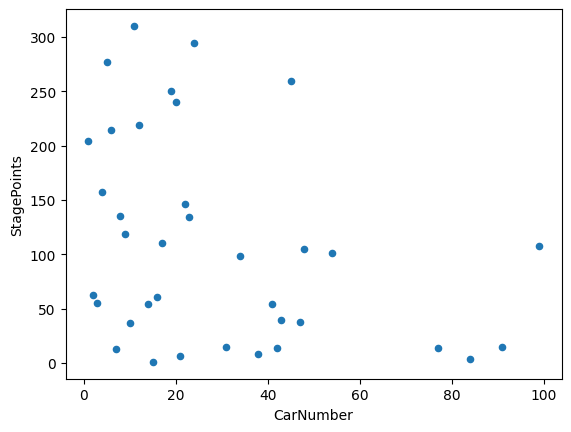

```python
cup_pts.plot(kind = 'scatter', x = 'CarNumber', y = 'StagePoints')
```

The above plot gives Cup Series Stage Points for each number. Unfortunately, the data on the x axis is in intervals so it makes the plot harder to read. With so many different car numbers, it will be hard to plot each of them on the plot without creating difficulties. It seems that in the Cup Series, the lower numbers scored more stage points than higher numbers.

**Conclusions**

From the above elementary data analysis, we answered some prototypical questions a person examining the dataset might ask. We also used each of the questions and applied them to the 3 different series in Nascar. Throughout the analysis, we utilized multiple different python techniques such as gropuing, summing, manipulating columns, plotting, and filtering. These techniques allowed for a simple yet in-depth analysis of Nascar stage racing data.